# ECON323_FINAL PROJECT

## ECON 323 FINAL PROJECT

> `Heart Attack Analysis & Prediction by Machine Learning Techniques`
- Group Members: `Eric Fang` `43975861` `Mingrui Li` `94413531` `Qinhuai Xu` `82194242`
- Section: 003

### Background

The dataset we cited originally from [Kaggle](https://www.kaggle.com/datasets/rashikrahmanpritom/heart-attack-analysis-prediction-dataset/code) is intended to provide an analysis and prediction to the heart attack by using corresponding machine learning models. The drive we planned to investigate this special topic can be attributed to [Simmons' findings in 2021](https://libres.uncg.edu/ir/ecsu/f/Brandon_Simmons_Thesis-Final.pdf), in which he clarified due to the complexity and the variations of the increasing number of risk factors, modern researchers are depending on Machine Learning techniques to make the further breakthroughs on this challenging topic. Besides, according to [Garg, Khan and Sharma(2020)](https://iopscience.iop.org/article/10.1088/1757-899X/1022/1/012046), Heart Attack Prediction by using machine learning technique has started to play a significant role in the medical care and other corresponding research fields.

### Outline

- Exploratory Data Analysis (EDA)

> During the EDA stage, our goal was to identify the main factors that contribute to the occurrence of heart attacks in the dataset. We are particularly interested in examining the impact of age on heart disease, as it is commonly assumed that older individuals are more susceptible to developing heart disease compared to younger individuals.
- Classification and Prediction

> > During the latter part of our project, we aim to utilize multiple machine learning models to forecast the likelihood of a heart attack using our dataset, and analyze their respective performances. The input features we consider span from the first to the thirteenth columns. The output value we're trying to predict is situated in the fourteenth column, named 'output', where the value 0 denotes a lower likelihood of a heart attack, while 1 indicates a higher likelihood. We intend to apply a total of six different models: `Random Forest`, `Gradient Boosting`, `Support Vector Machine`, `K-Nearest Neighbors`, `Naive Bayes`, and `Multi-layer Perceptron of Neural Network`.

> **Data Dictionary**

`age` - Age of the patient

`sex` - Sex of the patient

`cp` - Chest pain type - 0 = Typical Angina, 1 = Atypical Angina, 2 = Non-anginal Pain, 3 = Asymptomatic

`trtbps` - Resting blood pressure (in mm Hg)

`chol` - Cholestoral in mg/dl fetched via BMI sensor

`fbs` - (fasting blood sugar > 120 mg/dl) - 1 = True, 0 = False

`restecg` - Resting electrocardiographic results - 0 = Normal, 1 = ST-T wave normality, 2 = Left ventricular hypertrophy

`thalachh` - Maximum heart rate achieved

`oldpeak` - Previous peak

`slp` - Slope

`caa` - Number of major vessels

`thall` - Thalium Stress Test result - (0,3)

`exng` - Exercise induced angina - 1 = Yes, 0 = No

`output` - Target variable

> We kick off by loading all the needed libraries.

```python
import pandas as pd
import numpy as np
import matplotlib.pyplot as plt
import seaborn as sns
from sklearn.preprocessing import StandardScaler
from sklearn.model_selection import train_test_split
from sklearn.ensemble import RandomForestClassifier
from sklearn.metrics import f1_score
from sklearn import metrics
from sklearn.metrics import RocCurveDisplay
from sklearn.model_selection import RandomizedSearchCV
from sklearn.ensemble import GradientBoostingClassifier
from sklearn.svm import SVC
from sklearn.model_selection import GridSearchCV
from sklearn.neighbors import KNeighborsClassifier
from sklearn.neural_network import MLPClassifier
from sklearn.naive_bayes import GaussianNB
from sklearn import linear_model
import warnings
warnings.filterwarnings("ignore")
```

### Cleaning the Data

> Regularly, we first clean the data by checking out the potential missing values and drop it off.

```python
df = pd.read_csv('heart.csv')
df
```

|  | age | sex | cp | trtbps | chol | fbs | restecg | thalachh | exng | oldpeak | slp | caa | thall | output |
| --- | --- | --- | --- | --- | --- | --- | --- | --- | --- | --- | --- | --- | --- | --- |
| 0 | 63 | 1 | 3 | 145 | 233 | 1 | 0 | 150 | 0 | 2.3 | 0 | 0 | 1 | 1 |
| 1 | 37 | 1 | 2 | 130 | 250 | 0 | 1 | 187 | 0 | 3.5 | 0 | 0 | 2 | 1 |
| 2 | 41 | 0 | 1 | 130 | 204 | 0 | 0 | 172 | 0 | 1.4 | 2 | 0 | 2 | 1 |
| 3 | 56 | 1 | 1 | 120 | 236 | 0 | 1 | 178 | 0 | 0.8 | 2 | 0 | 2 | 1 |
| 4 | 57 | 0 | 0 | 120 | 354 | 0 | 1 | 163 | 1 | 0.6 | 2 | 0 | 2 | 1 |
| ... | ... | ... | ... | ... | ... | ... | ... | ... | ... | ... | ... | ... | ... | ... |
| 298 | 57 | 0 | 0 | 140 | 241 | 0 | 1 | 123 | 1 | 0.2 | 1 | 0 | 3 | 0 |
| 299 | 45 | 1 | 3 | 110 | 264 | 0 | 1 | 132 | 0 | 1.2 | 1 | 0 | 3 | 0 |
| 300 | 68 | 1 | 0 | 144 | 193 | 1 | 1 | 141 | 0 | 3.4 | 1 | 2 | 3 | 0 |
| 301 | 57 | 1 | 0 | 130 | 131 | 0 | 1 | 115 | 1 | 1.2 | 1 | 1 | 3 | 0 |
| 302 | 57 | 0 | 1 | 130 | 236 | 0 | 0 | 174 | 0 | 0.0 | 1 | 1 | 2 | 0 |

303 rows × 14 columns

```python
df.describe()
```

|  | age | sex | cp | trtbps | chol | fbs | restecg | thalachh | exng | oldpeak | slp | caa | thall | output |
| --- | --- | --- | --- | --- | --- | --- | --- | --- | --- | --- | --- | --- | --- | --- |
| count | 303.000000 | 303.000000 | 303.000000 | 303.000000 | 303.000000 | 303.000000 | 303.000000 | 303.000000 | 303.000000 | 303.000000 | 303.000000 | 303.000000 | 303.000000 | 303.000000 |
| mean | 54.366337 | 0.683168 | 0.966997 | 131.623762 | 246.264026 | 0.148515 | 0.528053 | 149.646865 | 0.326733 | 1.039604 | 1.399340 | 0.729373 | 2.313531 | 0.544554 |
| std | 9.082101 | 0.466011 | 1.032052 | 17.538143 | 51.830751 | 0.356198 | 0.525860 | 22.905161 | 0.469794 | 1.161075 | 0.616226 | 1.022606 | 0.612277 | 0.498835 |
| min | 29.000000 | 0.000000 | 0.000000 | 94.000000 | 126.000000 | 0.000000 | 0.000000 | 71.000000 | 0.000000 | 0.000000 | 0.000000 | 0.000000 | 0.000000 | 0.000000 |
| 25% | 47.500000 | 0.000000 | 0.000000 | 120.000000 | 211.000000 | 0.000000 | 0.000000 | 133.500000 | 0.000000 | 0.000000 | 1.000000 | 0.000000 | 2.000000 | 0.000000 |
| 50% | 55.000000 | 1.000000 | 1.000000 | 130.000000 | 240.000000 | 0.000000 | 1.000000 | 153.000000 | 0.000000 | 0.800000 | 1.000000 | 0.000000 | 2.000000 | 1.000000 |
| 75% | 61.000000 | 1.000000 | 2.000000 | 140.000000 | 274.500000 | 0.000000 | 1.000000 | 166.000000 | 1.000000 | 1.600000 | 2.000000 | 1.000000 | 3.000000 | 1.000000 |
| max | 77.000000 | 1.000000 | 3.000000 | 200.000000 | 564.000000 | 1.000000 | 2.000000 | 202.000000 | 1.000000 | 6.200000 | 2.000000 | 4.000000 | 3.000000 | 1.000000 |

```python
d = {}
for col in list(df.columns):
    d[col] = df[col].value_counts().shape[0]

pd.DataFrame(d, index=['Counts for indicator']).transpose()
```

|  | Counts for indicator |
| --- | --- |
| age | 41 |
| sex | 2 |
| cp | 4 |
| trtbps | 49 |
| chol | 152 |
| fbs | 2 |
| restecg | 3 |
| thalachh | 91 |
| exng | 2 |
| oldpeak | 40 |
| slp | 3 |
| caa | 5 |
| thall | 4 |
| output | 2 |

```python
df.info()
df.isnull().mean()
```

```
<class 'pandas.core.frame.DataFrame'>
RangeIndex: 303 entries, 0 to 302
Data columns (total 14 columns):
 #   Column    Non-Null Count  Dtype
---  ------    --------------  -----
 0   age       303 non-null    int64
 1   sex       303 non-null    int64
 2   cp        303 non-null    int64
 3   trtbps    303 non-null    int64
 4   chol      303 non-null    int64
 5   fbs       303 non-null    int64
 6   restecg   303 non-null    int64
 7   thalachh  303 non-null    int64
 8   exng      303 non-null    int64
 9   oldpeak   303 non-null    float64
 10  slp       303 non-null    int64
 11  caa       303 non-null    int64
 12  thall     303 non-null    int64
 13  output    303 non-null    int64
dtypes: float64(1), int64(13)
memory usage: 33.3 KB
```

```
age         0.0
sex         0.0
cp          0.0
trtbps      0.0
chol        0.0
fbs         0.0
restecg     0.0
thalachh    0.0
exng        0.0
oldpeak     0.0
slp         0.0
caa         0.0
thall       0.0
output      0.0
dtype: float64
```

However, the missing rate of this data set is 0 in terms of every indicators, which implies `there are no NAN values`.

### Visualization

> Followed by proceeding the data visualization.

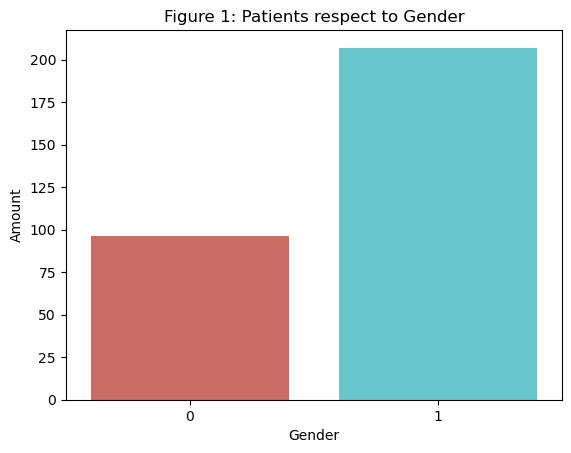

```python
sns.barplot(y=df['sex'].value_counts().values, x=df['sex'].value_counts().index, palette = 'hls')
plt.title('Figure 1: Patients respect to Gender')
plt.xlabel('Gender')
plt.ylabel('Amount')
plt.show()
```

The dataset includes **virtually over double the amount** of individuals classified as sex = 1 compared to those classified as sex = 0. (0 for `Female` and 1 for `Male` ).

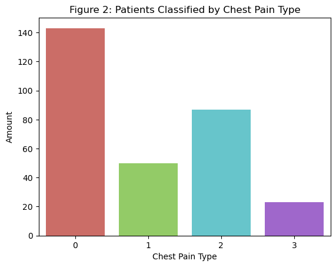

```python
sns.barplot(y=df['cp'].value_counts().values, x=df['cp'].value_counts().index, palette = 'hls')
plt.title('Figure 2: Patients Classified by Chest Pain Type')
plt.xlabel('Chest Pain Type')
plt.ylabel('Amount')
plt.show()
```

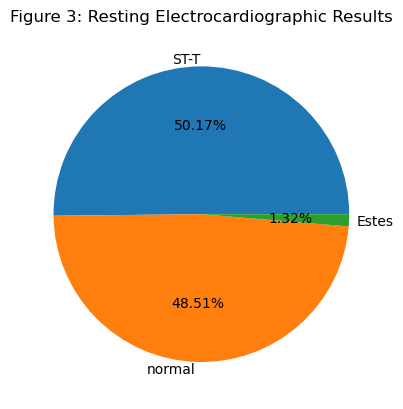

```python
plt.pie(df['restecg'].value_counts(),labels=['ST-T','normal', 'Estes'], autopct="%1.2f%%",
        textprops={'fontsize': 10}, labeldistance=1.05)
plt.title('Figure 3: Resting Electrocardiographic Results')
plt.show()
```

> From the result of resting electrocardiographic, only a small portion of patients show probable or definite left ventricular hypertrophy by Estes' criteria. Besides, the distribution is pretty even. It also highlights the **importance of individuals with abnormal ST-T values to take extra precautions regarding their heart health**, such as scheduling regular appointments with their physician for check-ups.

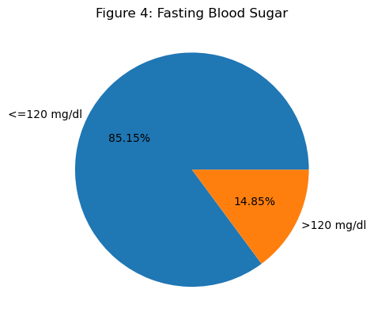

```python
plt.pie(df['fbs'].value_counts(),labels=['<=120 mg/dl', '>120 mg/dl'], autopct="%1.2f%%",
        textprops={'fontsize': 10}, labeldistance=1.05)
plt.title('Figure 4: Fasting Blood Sugar')
plt.show()
```

```
<function matplotlib.pyplot.show(close=None, block=None)>
```

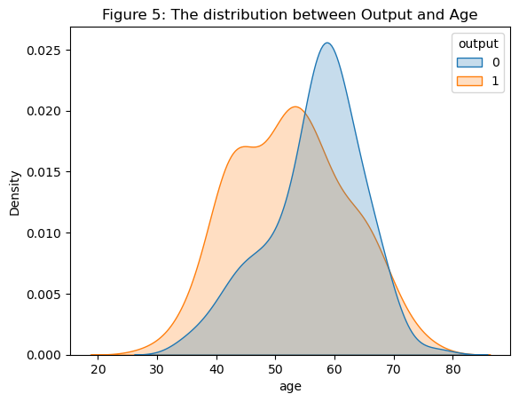

```python
sns.kdeplot(df['age'],hue=df['output'], shade = True)
plt.title('Figure 5: The distribution between Output and Age')
plt.show
```

> As depicted in the Distribution, the data suggests that the probability of having a heart disease decreases with age. It is commonly assumed that older individuals may have a higher risk of experiencing a heart attack. However, based on the distribution plot of age with respect to the output variable, **it is clear that this is not necessarily the case**. In addition, The graph shows that the peak period for heart disease, regardless of gender, is between 50-60 years old. Therefore, people should pay special attention to their heart health during this age range.

> We are very interested in understanding the relationship of Cholestoral with respect to Resting blood pressure.

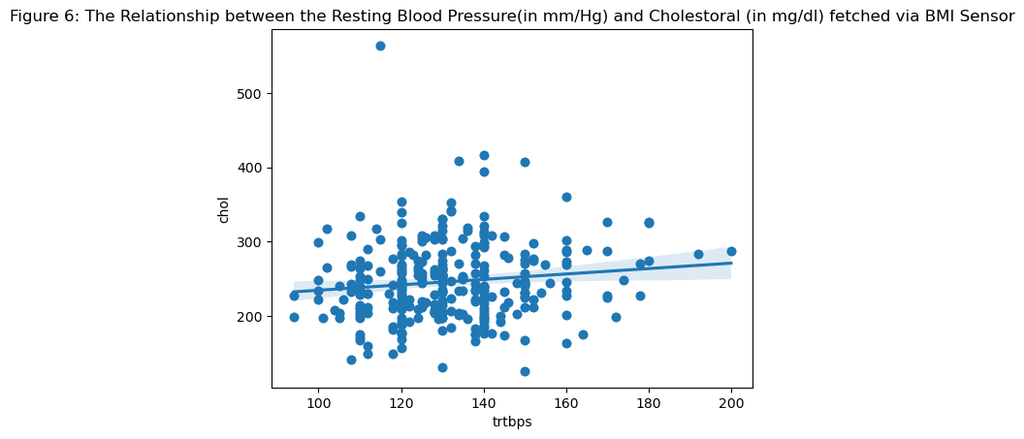

```python
plt.scatter(df['trtbps'], df['chol'])
sns.regplot(df['trtbps'], df['chol'], ci=95)
plt.xlabel('trtbps')
plt.ylabel('chol')
plt.title('Figure 6: The Relationship between the Resting Blood Pressure(in mm/Hg) and Cholestoral (in mg/dl) fetched via BMI Sensor')
plt.show()
```

> The fitted line is upward slopping, indicating a **positive correlation** between `Resting blood pressure` and `Cholestora`. Through the use of Naive Linear Regression Model, we are able to get the accurate correlation coefficient.

```python
lr_model = linear_model.LinearRegression()
lr_model.fit(df[['trtbps']], df['chol'])

para_1 = lr_model.intercept_
para_2 = lr_model.coef_[0]

print(f"Fitted model: log(total) = {para_1:.3f} + {para_2:.3f} log(chol)")
```

[output not shown]

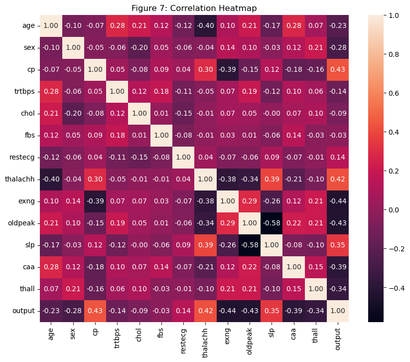

```python
plt.subplots(figsize=(10,8))
plt.title('Figure 7: Correlation Heatmap')
#ax = plt.axes()
###ax.set_title("Correlation Heatmap")
corr = df.corr()
sns.heatmap(corr, annot=True, fmt=".2f",
            xticklabels=corr.columns.values,
            yticklabels=corr.columns.values)
```

> The scatterplot heatmap matrix indicates a **potential correlation** between output and `Chest Pain`, `Maximum Heart Rate`, and `Slope`.

> We aim to assess the linearity of the variables, and to achieve this, we are plotting distribution graphs and examining the possible skewness of each feature.

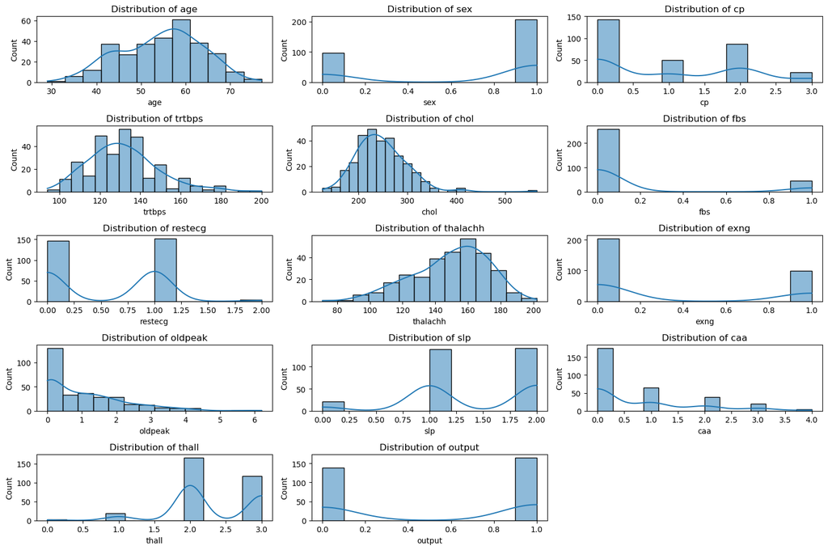

```python
plt.figure(figsize=(15,10))
for i,col in enumerate(df.columns,1):
    plt.subplot(5,3,i)
    plt.title(f"Distribution of {col}")
    sns.histplot(df[col],kde=True, palette = 'hls')
    plt.tight_layout()
    plt.plot()
```

> By observation, we can see that the overall distribution of Age, Cholestoral and Maximum heart rate achieved is close to a normal distribution.

[figure not shown]

```python
sns.pairplot(df,hue='output')
plt.show()
```

## Classification and Prediction

### Pre-processing

Import dataset into dataframe

```python
data = pd.read_csv('heart.csv')
data.head()
```

|  | age | sex | cp | trtbps | chol | fbs | restecg | thalachh | exng | oldpeak | slp | caa | thall | output |
| --- | --- | --- | --- | --- | --- | --- | --- | --- | --- | --- | --- | --- | --- | --- |
| 0 | 63 | 1 | 3 | 145 | 233 | 1 | 0 | 150 | 0 | 2.3 | 0 | 0 | 1 | 1 |
| 1 | 37 | 1 | 2 | 130 | 250 | 0 | 1 | 187 | 0 | 3.5 | 0 | 0 | 2 | 1 |
| 2 | 41 | 0 | 1 | 130 | 204 | 0 | 0 | 172 | 0 | 1.4 | 2 | 0 | 2 | 1 |
| 3 | 56 | 1 | 1 | 120 | 236 | 0 | 1 | 178 | 0 | 0.8 | 2 | 0 | 2 | 1 |
| 4 | 57 | 0 | 0 | 120 | 354 | 0 | 1 | 163 | 1 | 0.6 | 2 | 0 | 2 | 1 |

```python
y = data['output']
X = data.drop(columns = ['output'], axis = 1)
```

```python
scaler = StandardScaler()
X_transform = scaler.fit_transform(X)
X_transform.mean(axis=0)
```

```
array([ 4.69005106e-17, -1.40701532e-16,  2.34502553e-17, -7.03507659e-16,
       -1.11388713e-16, -2.34502553e-17,  1.46564096e-16, -6.80057404e-16,
       -4.69005106e-17,  2.34502553e-17, -1.40701532e-16, -2.34502553e-17,
       -1.64151787e-16])
```

> The dataset will be split into two separate sets: **a training set and a testing set**. The training set will consist of `80%` of the data, while the remaining `20%` will be allocated to the testing set. Our model will be trained using the training set, and its performance will be evaluated using the testing set.

```python
X_train, X_test, y_train, y_test = train_test_split(X, y, test_size = 0.2, random_state=43)
```

### Random Forest

```python
rf_model = RandomForestClassifier(max_depth = 15, random_state=0)
rf_model.fit(X_train, y_train)
pred = rf_model.predict(X_test)
print('default random forest f1 score is ', f1_score(y_test, pred, average = 'weighted'))
```

```
default random forest f1 score is  0.8844927984507591
```

> Create a graph of the ROC (Receiver Operating Characteristic) curve to display the model's performance. The ROC curve will illustrate the relationship between the `True Positive rate` and the `False Positive rate`. A ROC curve that is positioned close to the upper left corner indicates a high True Positive rate and a low False Positive rate.

```
<sklearn.metrics._plot.roc_curve.RocCurveDisplay at 0x7fd55a77af10>
```

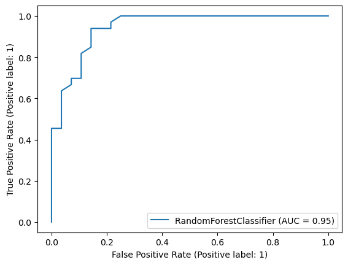

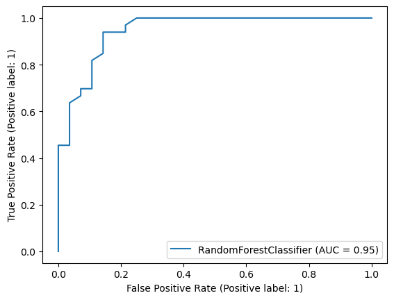

```python
# fpr, tpr, _ = metrics.roc_curve(y_test, pred, pos_label = 2)
roc_curve = RocCurveDisplay.from_estimator(rf_model, X_test, y_test)
roc_curve.plot()
```

> We will conduct a randomized search to enhance the performance of the random forest algorithm. The focus of this search will be on optimizing the hyperparameters, which includes the **maximum depth of the tree** and the **criterion used**.

```python
new_rf = RandomForestClassifier()
search_interval = dict(max_depth = range(5,40),
                     criterion = ['gini', 'entropy'])
ranSearchCV = RandomizedSearchCV(new_rf, search_interval, random_state=43)

ranSearchCV.fit(X_train, y_train)
```

```
RandomizedSearchCV(estimator=RandomForestClassifier(),
                   param_distributions={'criterion': ['gini', 'entropy'],
                                        'max_depth': range(5, 40)},
                   random_state=43)
```

```python
ranSearchCV.best_params_
```

```
{'max_depth': 11, 'criterion': 'entropy'}
```

```python
rf_model_best = RandomForestClassifier(max_depth = ranSearchCV.best_params_['max_depth'], random_state=43, criterion = ranSearchCV.best_params_['criterion'])
rf_model_best.fit(X_train, y_train)
pred = rf_model.predict(X_test)
print('optimized random forest f1 score is ', f1_score(y_test, pred, average = 'weighted'))
```

```
optimized random forest f1 score is  0.8844927984507591
```

### Gradient boosting

```python
gb = GradientBoostingClassifier(random_state = 43)
gb.fit(X_train, y_train)
pred_gb = gb.predict(X_test)
print('defaultgradient boosting model f1 score is ', f1_score(y_test, pred_gb, average = 'weighted'))
```

```
defaultgradient boosting model f1 score is  0.8675553954242479
```

> The performance of the gradient boosting model is slightly inferior to that of the random forest model. We believe that this could be due to the sensitivity of gradient boosting to outliers present in the dataset.

```
<sklearn.metrics._plot.roc_curve.RocCurveDisplay at 0x7fd55a56ffd0>
```

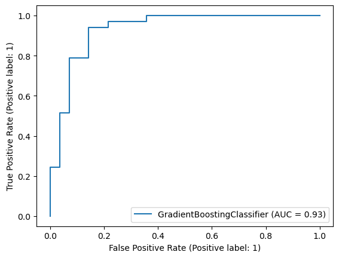

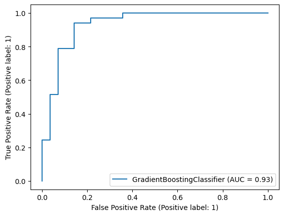

```python
roc_curve_gb = RocCurveDisplay.from_estimator(gb, X_test, y_test)
roc_curve_gb.plot()
```

### Support Vector Machine (SVM)

```python
svm = SVC()
svm.fit(X_train, y_train)
pred_svm = svm.predict(X_test)
print('default support vector machine classifier model f1 score is ', f1_score(y_test, pred_svm, average = 'weighted'))
```

```
default support vector machine classifier model f1 score is  0.6461748633879781
```

```python
param_grid = {
    'kernel' : ['linear', 'rbf', 'poly', 'sigmoid'],
    'C' : [0.1,1,10,100]
}
searchCV = GridSearchCV(SVC(), param_grid)
searchCV.fit(X_train, y_train)
```

```
GridSearchCV(estimator=SVC(),
             param_grid={'C': [0.1, 1, 10, 100],
                         'kernel': ['linear', 'rbf', 'poly', 'sigmoid']})
```

```python
searchCV.best_estimator_
```

```
SVC(C=10, kernel='linear')
```

```python
best_svm = searchCV.best_estimator_

pred_svm_best = best_svm.predict(X_test)
print('Tuned support vector machine classifier model f1 score is ', f1_score(y_test, pred_svm_best, average = 'weighted'))
```

```
Tuned support vector machine classifier model f1 score is  0.8998360655737705
```

```
<sklearn.metrics._plot.roc_curve.RocCurveDisplay at 0x7fd55a72bc70>
```

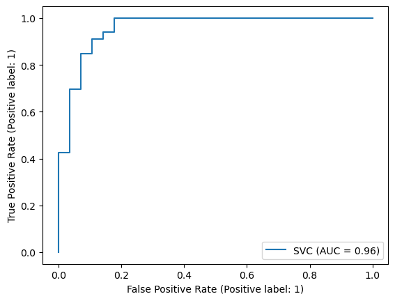

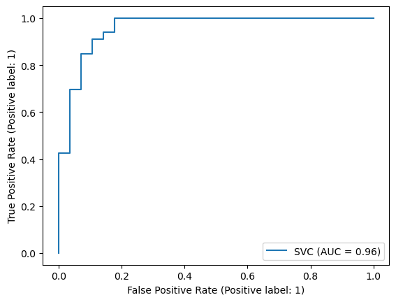

```python
roc_curve_svm = RocCurveDisplay.from_estimator(best_svm, X_test, y_test)
roc_curve_svm.plot()
```

### K-nearest neighbors (KNN)

```python
knn = KNeighborsClassifier(n_neighbors=5)
knn.fit(X_train, y_train)
pred_knn = knn.predict(X_test)
print('default k nearest neighbor classifier model f1 score is ', f1_score(y_test, pred_knn, average = 'weighted'))
```

```
default k nearest neighbor classifier model f1 score is  0.6534783953522775
```

> The default setting for the K-Nearest Neighbors (KNN) model did not yield satisfactory performance. Therefore, **we attempted to improve its performance by tuning hyperparameters**, such as the number of neighbors, the algorithm used, and the weight function applied.

```python
param_grid_knn = {
    'n_neighbors' : range(2,10),
    'algorithm' : ['ball_tree','kd_tree','auto', 'brute'],
    'weights' : ['uniform', 'distance']
}
searchCV = GridSearchCV(KNeighborsClassifier(), param_grid_knn, scoring='f1_weighted', cv=5)
searchCV.fit(X_train, y_train)
```

```
GridSearchCV(cv=5, estimator=KNeighborsClassifier(),
             param_grid={'algorithm': ['ball_tree', 'kd_tree', 'auto', 'brute'],
                         'n_neighbors': range(2, 10),
                         'weights': ['uniform', 'distance']},
             scoring='f1_weighted')
```

```python
searchCV.best_estimator_
```

```
KNeighborsClassifier(algorithm='ball_tree', n_neighbors=6)
```

```python
knn_best = searchCV.best_estimator_
pred_knn_best = knn_best.predict(X_test)
print('tuned knn classifier model f1 score is ', f1_score(y_test, pred_knn_best, average = 'weighted'))
```

```
tuned knn classifier model f1 score is  0.6399272187676653
```

> After comparing the performance of the default model and the hyperparameter tuned model, we have observed that **there has been no improvement** in the results when compared to other models. Additionally, the overall f1 score of this model is considerably lower than that of other models, which is undesirable. This could be attributed to the fact that the target label is linked to all attributes, and the relationship between each attribute is nonlinear.

```
<sklearn.metrics._plot.roc_curve.RocCurveDisplay at 0x7fd561140370>
```

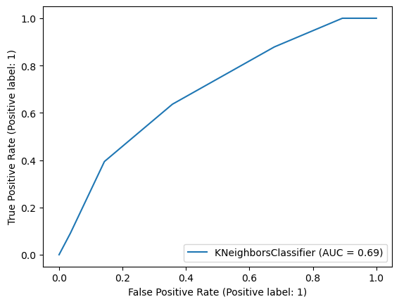

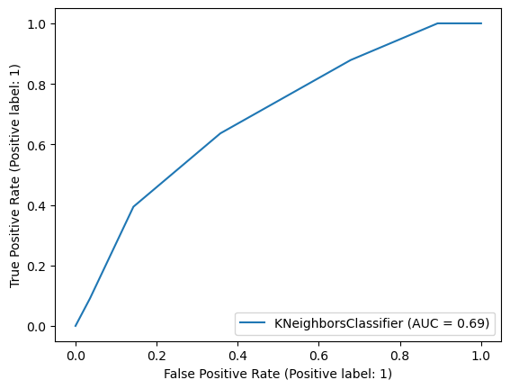

```python
roc_curve_knn = RocCurveDisplay.from_estimator(knn_best, X_test, y_test)
roc_curve_knn.plot()
```

### Naive Bayes

```python
naive_bayes_model = GaussianNB()
naive_bayes_model.fit(X_train, y_train)
pred_naive_bayes = naive_bayes_model.predict(X_test)
print('Naive Bayes model f1 score is ', f1_score(y_test, pred_naive_bayes, average = 'weighted'))
```

```
Naive Bayes model f1 score is  0.8998360655737705
```

> The Naive Bayes model has achieved an F1-score of around 90%. Based on the progress of the experiment thus far, it seems that the best possible model with the best parameters can attain a performance level of almost 90%. The results obtained from the aforementioned models suggest that unless additional data processing is performed or more data points are added, this is the optimal outcome we can expect. The Naive Bayes model applies Bayes' theorem to compute the conditional probability of each attribute among others. As per our understanding and the Scikit-learn website, **Naive Bayes works effectively even when provided with a small dataset**.

```
<sklearn.metrics._plot.roc_curve.RocCurveDisplay at 0x7fd5611609d0>
```

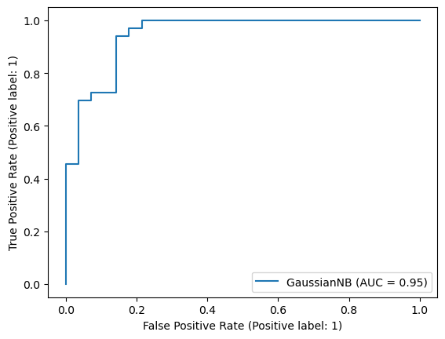

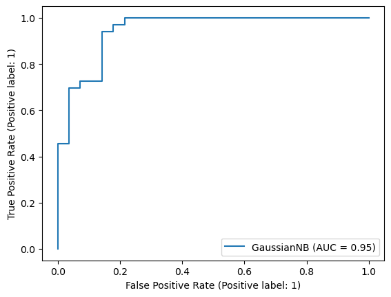

```python
roc_curve_nb = RocCurveDisplay.from_estimator(naive_bayes_model, X_test, y_test)
roc_curve_nb.plot()
```